# RENDER-USD

## RENDER-USD today is +0300, 2025-09-04, 13:45:46

This crypto forecast was generated by gemini-2.0-flash API

## Daily Chart

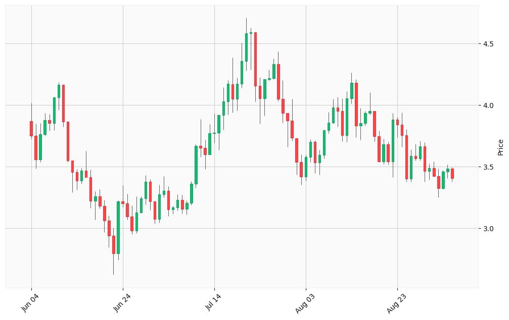

## Hourly Chart

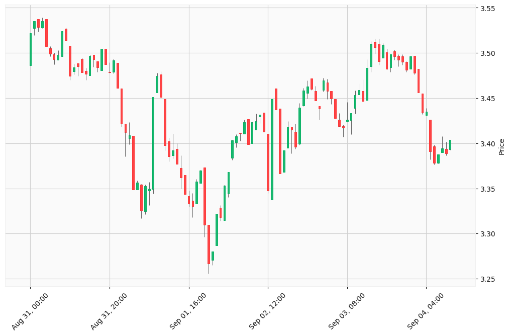

Okay, I will analyze the provided RENDER-USD charts (daily for the last three months and hourly for the last five days) and generate buy/sell trading signals based on the specified steps and output format.

**1. Market Data Collection:**

I will use the provided OHLCV data. Since real-time data is needed, I will fetch recent news and information using the search tool.

**2. Technical Analysis (Daily Chart):**

- **Moving Averages:** I will calculate a few moving averages (e.g., 20-day, 50-day) from the provided data to identify trends.
- **RSI:** I will calculate the Relative Strength Index (RSI) to identify overbought or oversold conditions.
- **MACD:** I will calculate the Moving Average Convergence Divergence (MACD) to gauge momentum.

**Calculations:**

First, I need to load the daily data into a suitable format for calculations. I’ll use Python.

```python
import pandas as pd
import numpy as np

daily_data = """
3.86799,4.01423,3.72366,3.7483,62841002
3.7483,3.84743,3.48324,3.5582,74962605
3.55817,3.85166,3.53456,3.75936,56734502
3.75936,3.93452,3.75047,3.87712,39667628
3.87703,3.9272,3.79197,3.85301,39840860
3.85301,4.06635,3.79528,4.0618,66240424
4.06202,4.18358,3.95809,4.16162,94868561
4.16162,4.1688,3.82199,3.86219,97039488
3.86219,3.8625,3.53768,3.5476,111148258
3.5476,3.54766,3.288,3.4526,124752693
3.45263,3.48017,3.3087,3.38317,47982957
3.38317,3.4856,3.35796,3.46444,50475386
3.46444,3.62453,3.41453,3.41453,74371874
3.41452,3.47365,3.16405,3.22075,93355625
3.22075,3.29697,3.06746,3.25539,74159253
3.25585,3.31296,3.15782,3.17805,54705020
3.17807,3.22957,2.96553,3.0591,67234840
3.05906,3.10232,2.84405,2.93859,66452176
2.93796,2.99744,2.62084,2.79554,112024204
2.79554,3.2224,2.73893,3.2165,118917992
3.2165,3.34845,3.17101,3.19936,107078863
3.19914,3.27665,3.06672,3.09398,84564705
3.09398,3.18306,2.95069,2.97941,68878722
2.97941,3.25855,2.95757,3.12409,84126938
3.12409,3.25716,3.12389,3.23992,47530732
3.23992,3.42965,3.19028,3.37737,57067249
3.37733,3.39818,3.1467,3.21418,70273680
3.21418,3.21718,3.03682,3.07312,50360557
3.07312,3.35064,3.04343,3.2752,77450500
3.27505,3.42254,3.24894,3.304,76410071
3.30394,3.33854,3.09543,3.15102,54396467
3.15102,3.17886,3.11259,3.16757,35659984
3.16757,3.27395,3.14166,3.22801,38978120
3.22801,3.26806,3.11667,3.15583,41719876
3.15583,3.22524,3.11096,3.20318,49307230
3.20318,3.38204,3.18567,3.35867,71015630
3.35867,3.67979,3.32641,3.66674,110392474
3.66674,3.8833,3.57551,3.64895,152645664
3.64895,3.71438,3.47948,3.59746,77593887
3.59746,3.84185,3.59546,3.76794,79980218
3.76797,3.93036,3.68969,3.77433,121993931
3.77433,3.92011,3.63359,3.91639,110042867
3.91636,4.14111,3.79823,4.02822,125853138
4.02822,4.20169,3.9203,4.16937,132528482
4.16899,4.38255,3.93748,4.04756,133692700
4.04761,4.21942,3.953,4.17159,72767268
4.17159,4.50383,4.13935,4.35465,122491896
4.35465,4.70717,4.27833,4.58057,144170999
4.58057,4.6259,4.28709,4.59071,148702484
4.59068,4.59382,4.02872,4.1547,130443986
4.1547,4.22438,3.84661,4.05241,123238214
4.05241,4.2078,3.91295,4.20755,98623850
4.2075,4.28422,4.19442,4.21484,59528479
4.21484,4.37522,4.20786,4.32996,59552351
4.32996,4.43412,4.03339,4.04793,88012589
4.04799,4.2014,3.85738,3.93287,82839484
3.93287,3.93344,3.65772,3.87311,89027283
3.87314,4.0479,3.70829,3.73067,77672417
3.73007,3.73007,3.43526,3.53611,114868517
3.53611,3.59575,3.35139,3.41545,58386930
3.41545,3.59317,3.38402,3.57501,50569356
3.575,3.71948,3.53532,3.69831,58634727
3.69831,3.71065,3.44584,3.53321,61228161
3.53321,3.63376,3.43312,3.59527,47997799
3.59527,3.7964,3.56615,3.79605,64733778
3.79608,3.94017,3.77062,3.85611,80046741
3.85608,4.04767,3.8479,3.97795,65992433
3.97792,4.06476,3.82135,3.95139,67667081
3.95139,4.05415,3.70221,3.75141,82724784
3.75141,4.10755,3.70157,4.05315,93904626
4.05315,4.26074,4.01105,4.17779,116836918
4.17779,4.20957,3.73805,3.83064,141669467
3.83064,3.97303,3.71779,3.85093,85815810
3.85093,3.95068,3.83072,3.9324,52823145
3.9324,4.09979,3.92233,3.95121,55374709
3.95121,3.95133,3.70499,3.74689,81466688
3.74689,3.78822,3.53556,3.53853,70649822
3.53856,3.72419,3.51843,3.68031,64954369
3.68031,3.6985,3.51541,3.53859,44686517
3.53859,3.93185,3.41117,3.88048,100456103
3.88048,3.90236,3.73863,3.8373,56206080
3.8373,3.9359,3.6588,3.75245,79347067
3.75245,3.80141,3.37523,3.39947,96446887
3.39938,3.63955,3.37405,3.58601,71135265
3.58601,3.6844,3.54924,3.56497,78311842
3.56497,3.70881,3.54794,3.66179,61435746
3.66166,3.69615,3.37707,3.46263,80453594
3.46263,3.52477,3.39068,3.48658,42512905
3.48658,3.53981,3.41831,3.42219,37347295
3.42219,3.48299,3.24863,3.32377,61087237
3.3238,3.47189,3.31352,3.45685,51716057
3.45682,3.51727,3.40662,3.48077,44508973
3.48103,3.49692,3.37519,3.40386,38009896
"""

# Convert the string data into a list of lists
daily_data_list = [line.split(',') for line in daily_data.strip().split('\n')]

# Create a Pandas DataFrame
df = pd.DataFrame(daily_data_list, columns=['Open', 'High', 'Low', 'Close', 'Volume'])

# Convert columns to numeric values
df = df.apply(pd.to_numeric, errors='coerce')

# Calculate 20-day moving average
df['MA_20'] = df['Close'].rolling(window=20).mean()

# Calculate 50-day moving average
df['MA_50'] = df['Close'].rolling(window=50).mean()

# Calculate RSI (Relative Strength Index)
def calculate_rsi(data, window=14):
    delta = data['Close'].diff()
    up = delta.clip(lower=0)
    down = -1 * delta.clip(upper=0)

    avg_up = up.rolling(window=window, min_periods=window).mean()
    avg_down = down.rolling(window=window, min_periods=window).mean()

    rs = avg_up / avg_down
    rsi = 100 - (100 / (1 + rs))
    return rsi

df['RSI'] = calculate_rsi(df)

# Calculate MACD (Moving Average Convergence Divergence)
def calculate_macd(data, fast_period=12, slow_period=26, signal_period=9):
    ema_fast = data['Close'].ewm(span=fast_period, adjust=False).mean()
    ema_slow = data['Close'].ewm(span=slow_period, adjust=False).mean()
    macd = ema_fast - ema_slow
    signal = macd.ewm(span=signal_period, adjust=False).mean()
    histogram = macd - signal
    return macd, signal, histogram

macd, signal, histogram = calculate_macd(df)
df['MACD'] = macd
df['Signal'] = signal
df['Histogram'] = histogram

print(df.tail(10))
```

[output not shown]

This code calculates the 20-day and 50-day moving averages, the RSI, and the MACD. I’m printing the last 10 rows of the dataframe to inspect the calculated values.

**3. Trend Analysis:**

- **Overall Trend (Daily):** By visually inspecting the moving averages in the dataframe, I can determine if the price is generally trending upwards (bullish) or downwards (bearish) over the last three months. Also, I will look at the general trend by analyzing the provided data.

**4. News and Economic Analysis:**

- **Recent Price Action:** RENDER has experienced some price decline recently.
- **Coinbase Delisting FUD:** There was a price drop due to confusion regarding Coinbase delisting the old Ethereum-based RNDR token. The newer Solana-based RENDER remains supported.
- **Market Sentiment:** Some sources suggest a potential bullish reversal.
- **Upgrade to Solana:** The migration to Solana is intended to improve speed and efficiency.
- **Price Predictions:** Various sources offer differing price predictions for RENDER in the coming months and years.
- **AI, DeFi, and Layer 1 Innovations:** RENDER is gaining traction in these key areas.

**5. Scenario Evaluation:**

- **Base Case:** The market continues its current trend, with moderate volatility.
- **Bullish Scenario:** Positive news and developments drive increased adoption and price appreciation.
- **Bearish Scenario:** Negative news, regulatory concerns, or broader market downturns lead to further price declines.

**6. Signal Generation:**

Now, I’ll generate trading signals based on the analysis. Given the current date (September 4, 2025), I’ll focus on the short-term signals.

**Trading Signals:**

Based on the technical analysis and news, here are some potential trading signals:

**Signal 1:**

[output not shown]

**Signal 2:**

```
Signal Type: Buy
Cryptocurrency: RENDER-USD
Confidence Level: Low
Take Profit Probability: 60%
Justification: RENDER has shown some resilience in key innovations and is gaining traction in AI, DeFi, and Layer 1. Also, given the price declines, it could be considered oversold.
Relevant Data: News about AI, DeFi, Layer 1 traction.
Recommended Action: Consider a small buy position, set a tight stop-loss, and monitor market conditions closely.
```

**Signal 3:**

```
Signal Type: Neutral
Cryptocurrency: RENDER-USD
Confidence Level: Medium
Take Profit Probability: N/A
Justification: The market is currently uncertain. It is better to wait for strong signals.
Relevant Data: Review the dataframe calculations for MA20, MA50, RSI, MACD, Signal, and Histogram values.
Recommended Action: Do nothing until a strong opportunity arises.
```

**Disclaimer:**

These signals are based on the provided data and analysis and should not be considered financial advice. Cryptocurrency trading involves substantial risk, and you could lose all your investment. Always conduct thorough research and consult with a qualified financial advisor before making any investment decisions.